# Analisis exploratorio de dataSet ‘House-Pricing’

## 6.8 Outliers Price

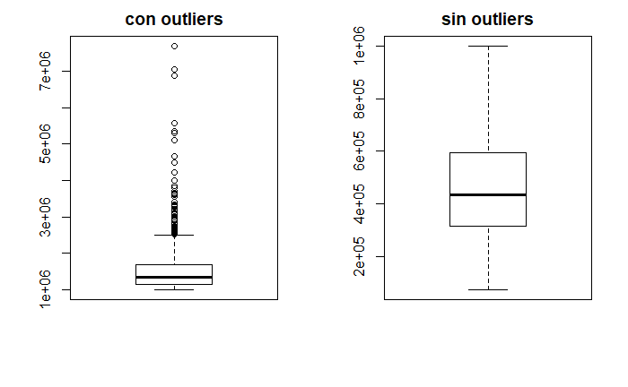

```r
price_con_outliers= filter(a_raw_data,price>1000000)
price_sin_outliers= filter(a_raw_data,!price>1000000)

par(mfrow = c(1,2))
boxplot(price_con_outliers$price, main="con outliers")
boxplot(price_sin_outliers$price, main="sin outliers")
```

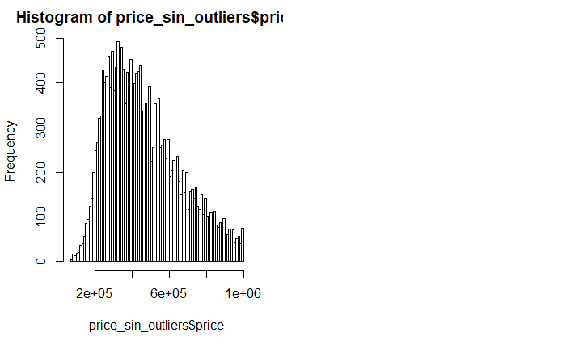

```r
hist(price_sin_outliers$price, breaks = 100)
```

```r
summary(price_sin_outliers$price)
```

```
   Min. 1st Qu.  Median    Mean 3rd Qu.    Max.
  75000  314000  434000  467701  593600 1000000
```

## 6.9 Relacion sqft con las sqft de 2015

De aca deducimos que esto se refiere a los valores actuales. Por lo cual en un futuro quizas decida quedarme con los 15

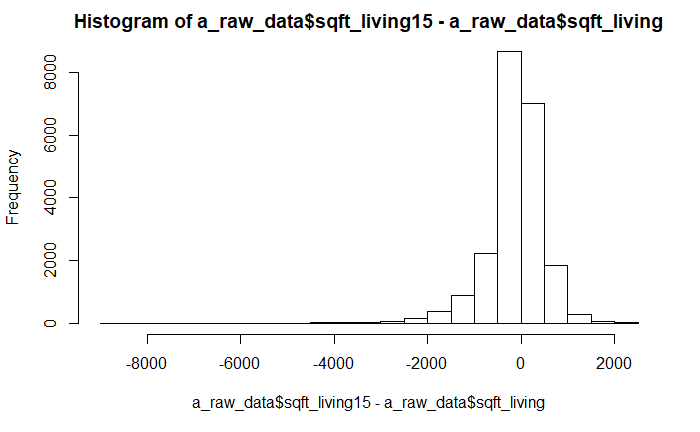

```r
hist(a_raw_data$sqft_living15-a_raw_data$sqft_living)
```

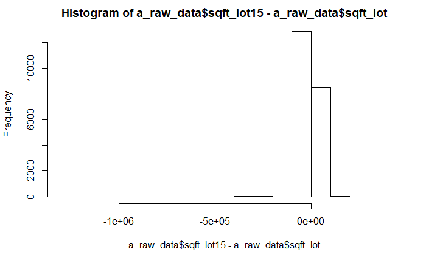

```r
hist(a_raw_data$sqft_lot15-a_raw_data$sqft_lot)
```

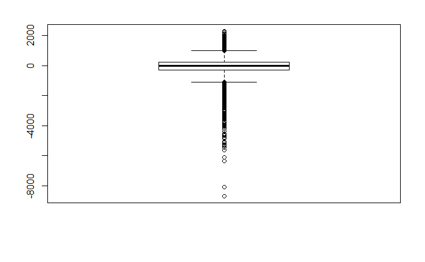

```r
boxplot(a_raw_data$sqft_living15-a_raw_data$sqft_living)
```

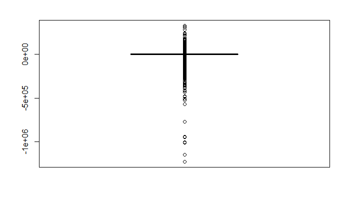

```r
boxplot(a_raw_data$sqft_lot15-a_raw_data$sqft_lot)
```

### 6.9.1 Outliers de sqft_lot15

Creo que seria conveniente sacar algunos valores de lot15 bastante grandes

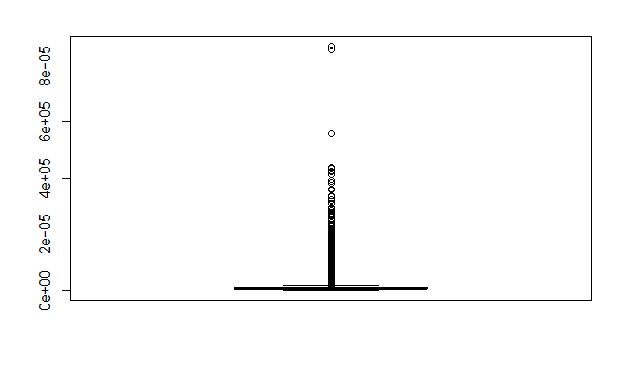

```r
boxplot(a_raw_data$sqft_lot15)
```

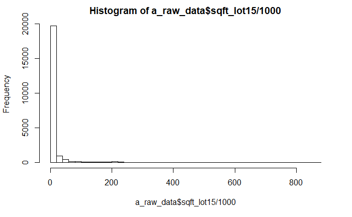

```r
hist(a_raw_data$sqft_lot15/1000, breaks=40)
```

```r
dim(filter(a_raw_data,(sqft_lot15/1000)>100))
```

```
[1] 341  20
```

```r
lot15=filter(a_raw_data,(sqft_lot15/1000)<=100)
dim(lot15)
```

```
[1] 21272    20
```

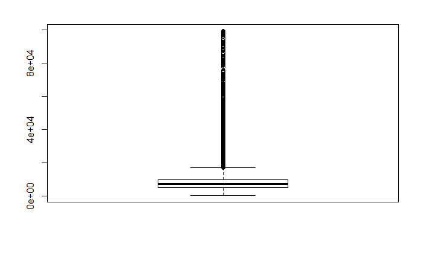

```r
boxplot(lot15$sqft_lot15)
```

### 6.9.2 Outliers de sqft_living15

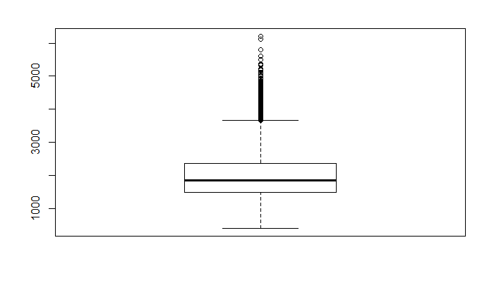

```r
boxplot(a_raw_data$sqft_living15)
```

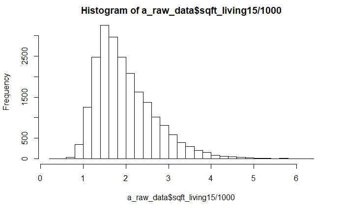

```r
hist(a_raw_data$sqft_living15/1000, breaks=40)
```

```r
dim(filter(a_raw_data,(sqft_living15/1000)>4))
```

```
[1] 254  20
```

```r
living15=filter(a_raw_data,(sqft_living15/1000)<=4)
dim(living15)
```

```
[1] 21359    20
```

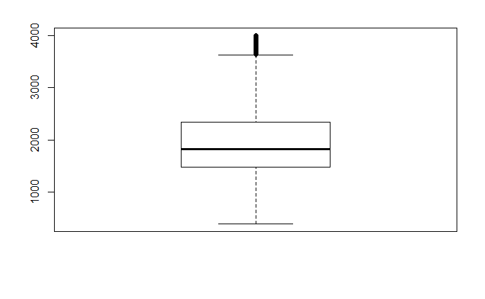

```r
boxplot(living15$sqft_living15)
```

## 6.10 Outliers Price

creo que filtrar por sqft_price no afecta demaciado al pareces, aunque puede que en la regresion lineal se muestre alguna mejora

```r
precio_lot=mutate(a_raw_data,sqft_price=price/sqft_living15)
summary(precio_lot$sqft_price)
```

```
   Min. 1st Qu.  Median    Mean 3rd Qu.    Max.
  39.51  183.02  246.15  270.43  320.61 1954.31
```

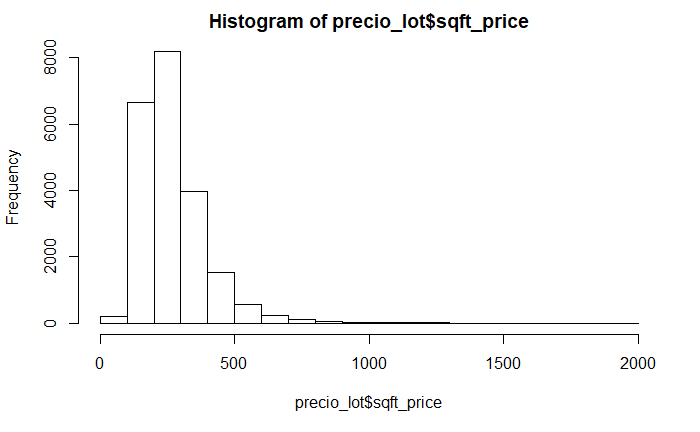

```r
hist(precio_lot$sqft_price)
```

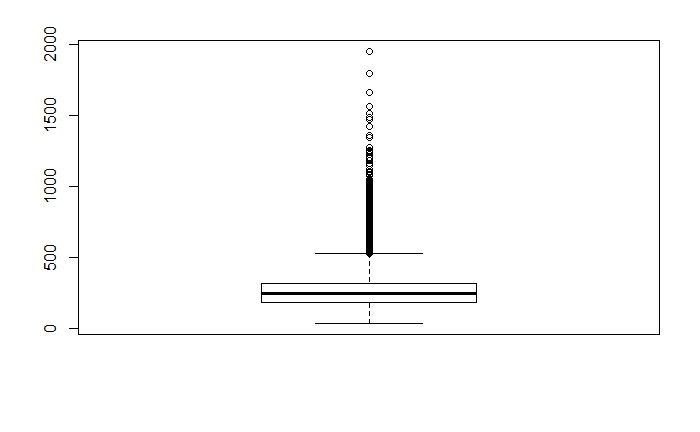

```r
boxplot(precio_lot$sqft_price)
```

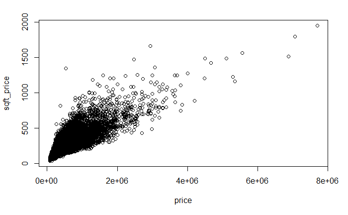

```r
plot(sqft_price~price,data=precio_lot)
```

```r
precio_lot2=filter(precio_lot,sqft_price>13)
precio_lot2=filter(precio_lot2,sqft_price<500)
precio_lot2=filter(precio_lot2,price<1000000)

summary(precio_lot2$sqft_price)
```

```
   Min. 1st Qu.  Median    Mean 3rd Qu.    Max.
  39.51  177.48  234.94  245.25  297.87  499.97
```

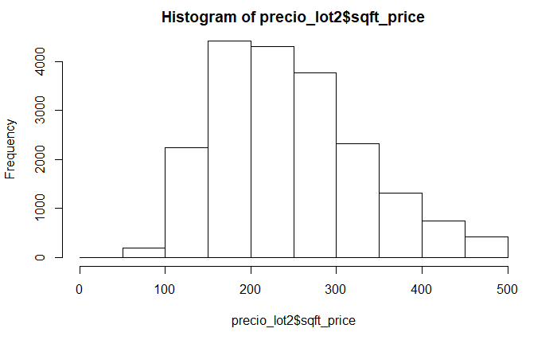

```r
hist(precio_lot2$sqft_price)
```

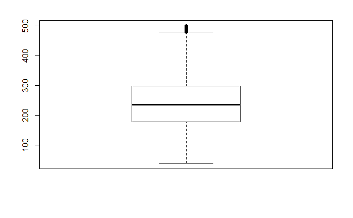

```r
boxplot(precio_lot2$sqft_price)
```

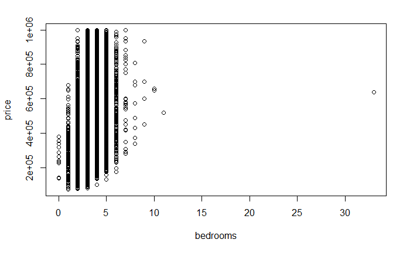

```r
plot(price~bedrooms,data=precio_lot2)
```

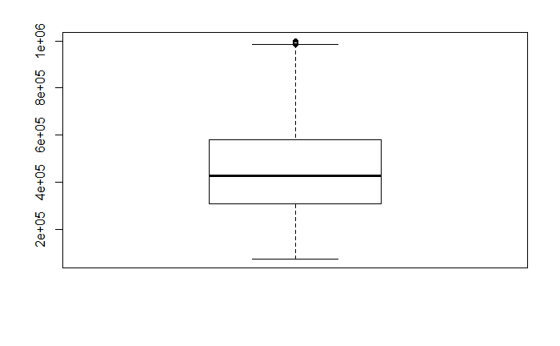

```r
boxplot(precio_lot2$price)
```

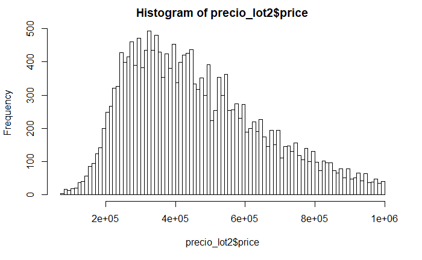

```r
hist(precio_lot2$price, breaks = 100)
```

### 6.10.1 Regresion lineal

Luego de esta prueba con las variables que tenia pensado quitar me dio unas graficas interesantes y un R2 de 46 y quitando 2000 elemntos que masomens seria el 10%

```r
lm_sin_condicion <- lm(formula = price ~ . , data = select(precio_lot2, -c("date",  "condition","sqft_basement","sqft_above","sqft_price","lat","long","sqft_living","sqft_lot","yr_built","yr_renovated","view","waterfront")))
summary(lm_sin_condicion)
```

```
Call:
lm(formula = price ~ ., data = select(precio_lot2, -c("date",
    "condition", "sqft_basement", "sqft_above", "sqft_price",
    "lat", "long", "sqft_living", "sqft_lot", "yr_built", "yr_renovated",
    "view", "waterfront")))

Residuals:
    Min      1Q  Median      3Q     Max
-461693 -101917  -11388   88995  597565

Coefficients:
                Estimate Std. Error t value Pr(>|t|)
(Intercept)   -5.301e+07  1.924e+06 -27.547  < 2e-16 ***
bedrooms       9.089e+03  1.284e+03   7.077 1.52e-12 ***
bathrooms      1.220e+04  2.107e+03   5.790 7.16e-09 ***
floors        -8.388e+03  2.238e+03  -3.749 0.000178 ***
grade          7.480e+04  1.502e+03  49.794  < 2e-16 ***
zipcode        5.370e+02  1.961e+01  27.381  < 2e-16 ***
sqft_living15  1.061e+02  2.416e+00  43.934  < 2e-16 ***
sqft_lot15     5.587e-02  3.899e-02   1.433 0.151920
---
Signif. codes:  0 ‘***’ 0.001 ‘**’ 0.01 ‘*’ 0.05 ‘.’ 0.1 ‘ ’ 1

Residual standard error: 139700 on 19737 degrees of freedom
Multiple R-squared:  0.4666,    Adjusted R-squared:  0.4664
F-statistic:  2466 on 7 and 19737 DF,  p-value: < 2.2e-16
```

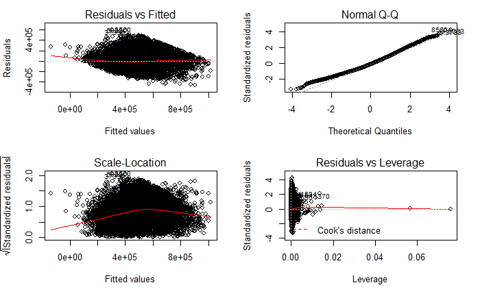

```r
par(mfrow=c(2,2))
plot(lm_sin_condicion)
```

```r
#correlation<-round(cor(var1[,4:22]),2)
#corAvg<-colMeans (correlation[ , 1:19])
#corAvg<-data.frame(corAvg)
#correlation
#corAvg[order(corAvg$corAvg,decreasing = TRUE),]

#imcdiag(select(data_set, -c("Price")), data_set$Price)

#correlation<-round(cor(var1[,4:22]),2)
#corAvg<-colMeans (correlation[ , 1:19])
#corAvg
```

### 6.11 Bathrooms bedrooms

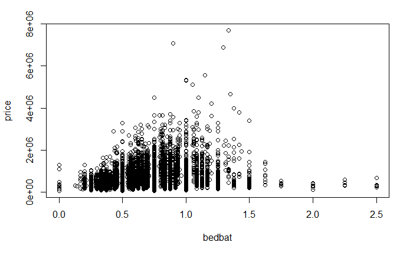

```r
data_bb=filter(a_raw_data,bedrooms<15)
data_bb=mutate(data_bb,bedbat=ifelse(bedrooms>0,bathrooms/bedrooms,bathrooms))
plot(price~bedbat,data=data_bb)
```

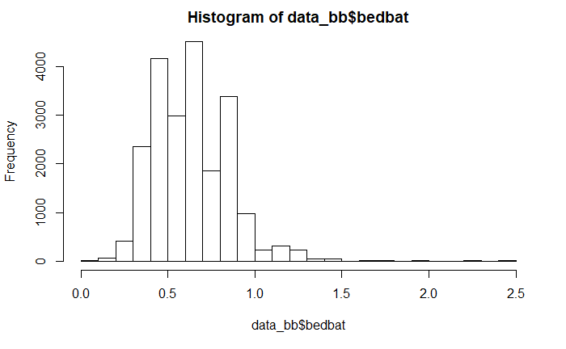

```r
hist(data_bb$bedbat,breaks=30)
```

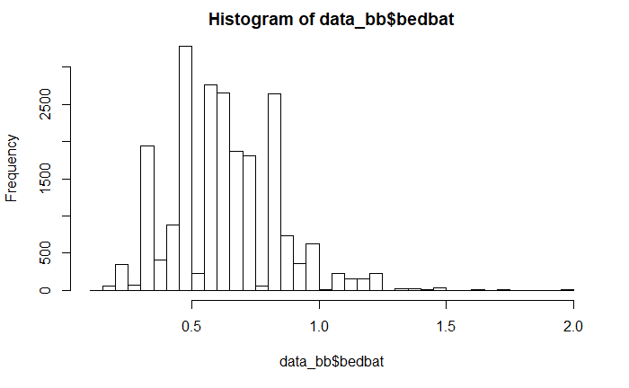

```r
data_bb=filter(data_bb,bedbat>0)
data_bb=filter(data_bb,bedbat<=2)
hist(data_bb$bedbat,breaks=30)
```

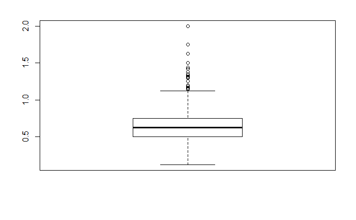

```r
boxplot(data_bb$bedbat)
```

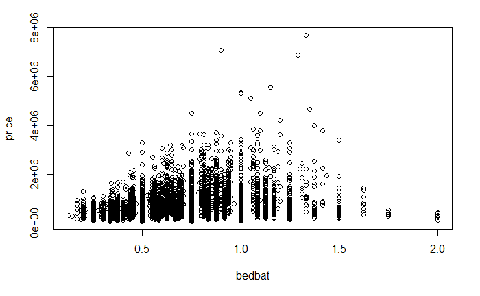

```r
plot(price~bedbat,data=data_bb)
```

```r
summary(lm(price~bedbat,data=data_bb))
```

```
Call:
lm(formula = price ~ bedbat, data = data_bb)

Residuals:
     Min       1Q   Median       3Q      Max
-1100808  -200412   -74411   108314  6815524

Coefficients:
            Estimate Std. Error t value Pr(>|t|)
(Intercept)   221813       7697   28.82   <2e-16 ***
bedbat        496997      11418   43.53   <2e-16 ***
---
Signif. codes:  0 ‘***’ 0.001 ‘**’ 0.01 ‘*’ 0.05 ‘.’ 0.1 ‘ ’ 1

Residual standard error: 352100 on 21591 degrees of freedom
Multiple R-squared:  0.08067,   Adjusted R-squared:  0.08063
F-statistic:  1895 on 1 and 21591 DF,  p-value: < 2.2e-16
```

```r
summary(lm(price~bedrooms,data=data_bb))
```

```
Call:
lm(formula = price ~ bedrooms, data = data_bb)

Residuals:
    Min      1Q  Median      3Q     Max
-999583 -202813  -64418  105791 6822395

Coefficients:
            Estimate Std. Error t value Pr(>|t|)
(Intercept)   107231       9153   11.71   <2e-16 ***
bedrooms      128396       2622   48.97   <2e-16 ***
---
Signif. codes:  0 ‘***’ 0.001 ‘**’ 0.01 ‘*’ 0.05 ‘.’ 0.1 ‘ ’ 1

Residual standard error: 348300 on 21591 degrees of freedom
Multiple R-squared:  0.09997,   Adjusted R-squared:  0.09993
F-statistic:  2398 on 1 and 21591 DF,  p-value: < 2.2e-16
```

```r
summary(lm(price~bathrooms,data=data_bb))
```

```
Call:
lm(formula = price ~ bathrooms, data = data_bb)

Residuals:
     Min       1Q   Median       3Q      Max
-1442205  -184697   -41196   113253  5923600

Coefficients:
            Estimate Std. Error t value Pr(>|t|)
(Intercept)     8943       6220   1.438    0.151
bathrooms     251102       2763  90.878   <2e-16 ***
---
Signif. codes:  0 ‘***’ 0.001 ‘**’ 0.01 ‘*’ 0.05 ‘.’ 0.1 ‘ ’ 1

Residual standard error: 312300 on 21591 degrees of freedom
Multiple R-squared:  0.2767,    Adjusted R-squared:  0.2766
F-statistic:  8259 on 1 and 21591 DF,  p-value: < 2.2e-16
```

### 6.12 Zipcode relacion con lat y long

```r
dim15=a_raw_data
#zipcodepro$zipcode=as.factor(zipcodepro$zipcode)
dim15= mutate(dim15,livingdif=sqft_living-sqft_living15)

summary(dim15$livingdif)
```

```
    Min.  1st Qu.   Median     Mean  3rd Qu.     Max.
-2310.00  -220.00     0.00    93.35   310.00  8690.00
```

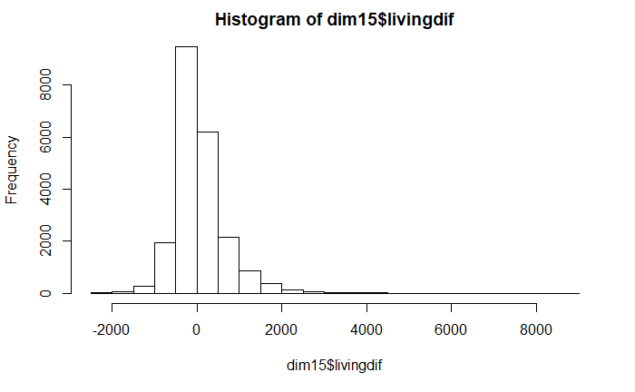

```r
hist(dim15$livingdif)
```

```r
modelo_zipcode= lm(price~zipcode,data=a_raw_data)
summary(modelo_zipcode)
```

```
Call:
lm(formula = price ~ zipcode, data = a_raw_data)

Residuals:
    Min      1Q  Median      3Q     Max
-485509 -217931  -87059  103506 7168695

Coefficients:
              Estimate Std. Error t value Pr(>|t|)
(Intercept)  3.634e+07  4.571e+06   7.950 1.95e-15 ***
zipcode     -3.651e+02  4.661e+01  -7.832 5.01e-15 ***
---
Signif. codes:  0 ‘***’ 0.001 ‘**’ 0.01 ‘*’ 0.05 ‘.’ 0.1 ‘ ’ 1

Residual standard error: 366600 on 21611 degrees of freedom
Multiple R-squared:  0.002831,  Adjusted R-squared:  0.002784
F-statistic: 61.34 on 1 and 21611 DF,  p-value: 5.011e-15
```

```r
modelo_latlong= lm(price~as.numeric(long)+as.numeric(lat),data=a_raw_data)
summary(modelo_latlong)
```

```
Call:
lm(formula = price ~ as.numeric(long) + as.numeric(lat), data = a_raw_data)

Residuals:
    Min      1Q  Median      3Q     Max
-673068 -181550  -75971   73129 7119886

Coefficients:
                  Estimate Std. Error t value Pr(>|t|)
(Intercept)      -18724091    2127683   -8.80   <2e-16 ***
as.numeric(long)    167916      16996    9.88   <2e-16 ***
as.numeric(lat)     836538      17274   48.43   <2e-16 ***
---
Signif. codes:  0 ‘***’ 0.001 ‘**’ 0.01 ‘*’ 0.05 ‘.’ 0.1 ‘ ’ 1

Residual standard error: 348600 on 21610 degrees of freedom
Multiple R-squared:  0.09832,   Adjusted R-squared:  0.09824
F-statistic:  1178 on 2 and 21610 DF,  p-value: < 2.2e-16
```

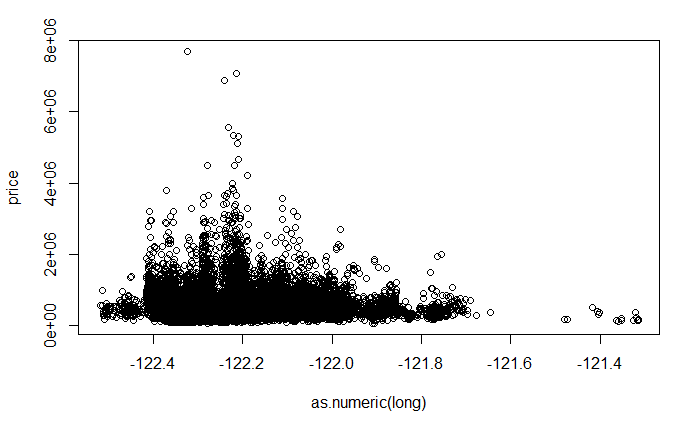

```r
plot(price~as.numeric(long)+as.numeric(lat),data=a_raw_data)
```

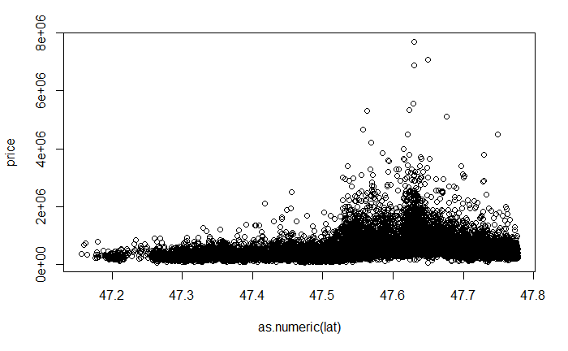

```r
par(mfrow = c(1,2))
```

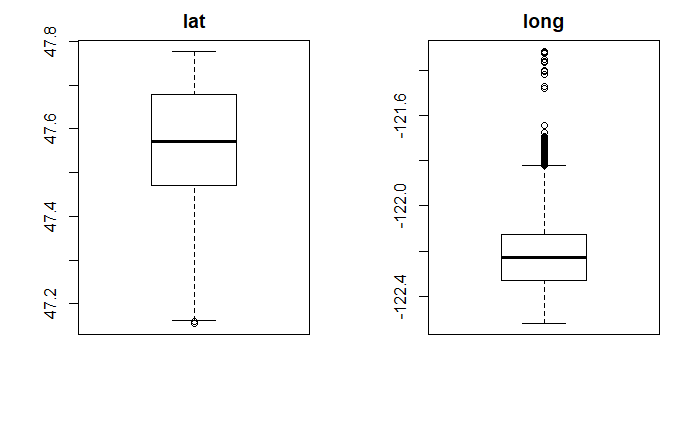

```r
boxplot(as.numeric(a_raw_data$lat), main="lat")
boxplot(as.numeric(a_raw_data$long), main="long")
```

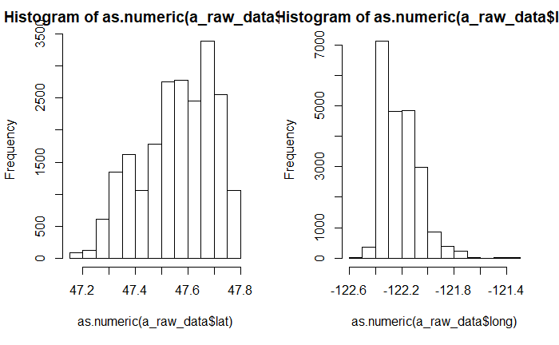

```r
hist(as.numeric(a_raw_data$lat))
hist(as.numeric(a_raw_data$long))
```

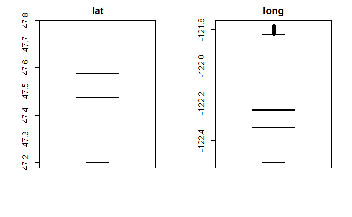

```r
data_latlong=a_raw_data
data_latlong$long=as.numeric(data_latlong$long)
data_latlong$lat=as.numeric(data_latlong$lat)
data_latlong=filter(data_latlong,long<(-121.78))
data_latlong=filter(data_latlong,lat>(47.2))
boxplot(data_latlong$lat, main="lat")
boxplot(data_latlong$long, main="long")
```

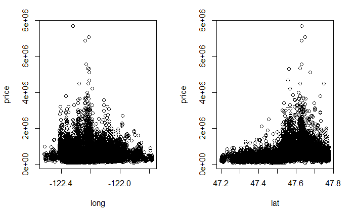

```r
modelo_latlong= lm(price~long+lat,data=data_latlong)
plot(price~long+lat,data=data_latlong)
```

```r
summary(modelo_latlong)
```

```
Call:
lm(formula = price ~ long + lat, data = data_latlong)

Residuals:
    Min      1Q  Median      3Q     Max
-618235 -181642  -76293   72999 7122760

Coefficients:
             Estimate Std. Error t value Pr(>|t|)
(Intercept) -13695253    2292786  -5.973 2.36e-09 ***
long           211922      18279  11.594  < 2e-16 ***
lat            843914      17561  48.056  < 2e-16 ***
---
Signif. codes:  0 ‘***’ 0.001 ‘**’ 0.01 ‘*’ 0.05 ‘.’ 0.1 ‘ ’ 1

Residual standard error: 349600 on 21319 degrees of freedom
Multiple R-squared:  0.09914,   Adjusted R-squared:  0.09906
F-statistic:  1173 on 2 and 21319 DF,  p-value: < 2.2e-16
```

### 6.14 view y waterfront

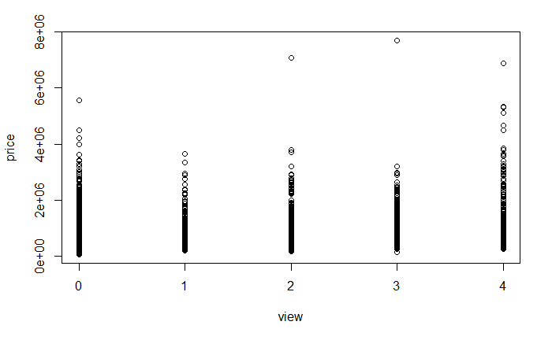

```r
plot(price~view,data=a_raw_data)
```

```r
summary(lm(price~view,data=a_raw_data))
```

```
Call:
lm(formula = price ~ view, data = a_raw_data)

Residuals:
     Min       1Q   Median       3Q      Max
-1004833  -195492   -67492   109508  6633502

Coefficients:
            Estimate Std. Error t value Pr(>|t|)
(Intercept)   495492       2396  206.76   <2e-16 ***
view          190335       2991   63.64   <2e-16 ***
---
Signif. codes:  0 ‘***’ 0.001 ‘**’ 0.01 ‘*’ 0.05 ‘.’ 0.1 ‘ ’ 1

Residual standard error: 336900 on 21611 degrees of freedom
Multiple R-squared:  0.1578,    Adjusted R-squared:  0.1578
F-statistic:  4050 on 1 and 21611 DF,  p-value: < 2.2e-16
```

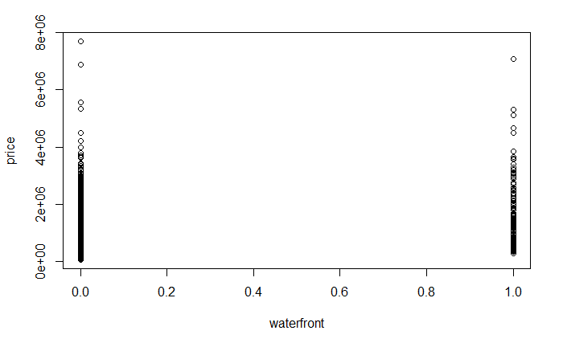

```r
plot(price~waterfront,data=a_raw_data)
```

```r
summary(lm(price~waterfront,data=a_raw_data))
```

```
Call:
lm(formula = price ~ waterfront, data = a_raw_data)

Residuals:
     Min       1Q   Median       3Q      Max
-1376876  -211564   -81564   108436  7168436

Coefficients:
            Estimate Std. Error t value Pr(>|t|)
(Intercept)   531564       2416  220.00   <2e-16 ***
waterfront   1130312      27823   40.63   <2e-16 ***
---
Signif. codes:  0 ‘***’ 0.001 ‘**’ 0.01 ‘*’ 0.05 ‘.’ 0.1 ‘ ’ 1

Residual standard error: 353900 on 21611 degrees of freedom
Multiple R-squared:  0.07095,   Adjusted R-squared:  0.07091
F-statistic:  1650 on 1 and 21611 DF,  p-value: < 2.2e-16
```

```r
summary(lm(price~waterfront+view,data=a_raw_data))
```

```
Call:
lm(formula = price ~ waterfront + view, data = a_raw_data)

Residuals:
     Min       1Q   Median       3Q      Max
-1415537  -195160   -67160   108840  6705339

Coefficients:
            Estimate Std. Error t value Pr(>|t|)
(Intercept)   497160       2379  209.00   <2e-16 ***
waterfront    540042      28695   18.82   <2e-16 ***
view          165834       3240   51.19   <2e-16 ***
---
Signif. codes:  0 ‘***’ 0.001 ‘**’ 0.01 ‘*’ 0.05 ‘.’ 0.1 ‘ ’ 1

Residual standard error: 334200 on 21610 degrees of freedom
Multiple R-squared:  0.1714,    Adjusted R-squared:  0.1713
F-statistic:  2235 on 2 and 21610 DF,  p-value: < 2.2e-16
```

# 7 Modelo

## 7.1 Modelo 1

### 1 Limpieza Modelo Daniel

```r
clean_data= a_raw_data


## lot15 y living15
clean_data=filter(clean_data,(sqft_living15/1000)<=4)
clean_data=filter(clean_data,(sqft_lot15/1000)<=100)

#Precio/Sqft
clean_data=filter(clean_data,price/sqft_living15>13)
clean_data=filter(clean_data,price/sqft_living15<500)
clean_data=filter(clean_data,price<1000000)


#bathrooms bethrooms
clean_data=mutate(clean_data,bedbat=ifelse(bedrooms>0,bathrooms/bedrooms,bathrooms))
clean_data=filter(clean_data,bedrooms<15)
clean_data=filter(clean_data,bedbat>0)
clean_data=filter(clean_data,bedbat<=2)
clean_data=mutate(clean_data,bathrooms= round(as.double(bathrooms)))


#zip code lat y long
data_latlong$long=as.numeric(data_latlong$long)
data_latlong$lat=as.numeric(data_latlong$lat)
data_latlong=filter(data_latlong,long<(-121.78))
data_latlong=filter(data_latlong,lat>(47.2))

# Fecha a antiguedad
clean_data$date =  as.Date(clean_data$date, format = "%Y%m%dT000000")
clean_data= mutate(clean_data,antiguedad = ifelse(yr_renovated>0,yr_renovated-yr_built,year(date)-yr_built))
clean_data= mutate(clean_data,antiguedad = ifelse(antiguedad>0,antiguedad,0))

#clean_data$price=clean_data$price/mean(clean_data$price)
```

### 2 Regresiones lineales

```r
summary(lm(price~bedrooms,data=clean_data))
```

```
Call:
lm(formula = price ~ bedrooms, data = clean_data)

Residuals:
    Min      1Q  Median      3Q     Max
-453958 -143731  -25524  116927  622971

Coefficients:
            Estimate Std. Error t value Pr(>|t|)
(Intercept)   248305       5098   48.71   <2e-16 ***
bedrooms       63442       1486   42.69   <2e-16 ***
---
Signif. codes:  0 ‘***’ 0.001 ‘**’ 0.01 ‘*’ 0.05 ‘.’ 0.1 ‘ ’ 1

Residual standard error: 181800 on 19367 degrees of freedom
Multiple R-squared:  0.08599,   Adjusted R-squared:  0.08595
F-statistic:  1822 on 1 and 19367 DF,  p-value: < 2.2e-16
```

```r
summary(lm(price~bathrooms,data=clean_data))
```

```
Call:
lm(formula = price ~ bathrooms, data = clean_data)

Residuals:
    Min      1Q  Median      3Q     Max
-653974 -134720  -23105  110452  612280

Coefficients:
            Estimate Std. Error t value Pr(>|t|)
(Intercept)   219835       3800   57.85   <2e-16 ***
bathrooms     117885       1774   66.44   <2e-16 ***
---
Signif. codes:  0 ‘***’ 0.001 ‘**’ 0.01 ‘*’ 0.05 ‘.’ 0.1 ‘ ’ 1

Residual standard error: 171600 on 19367 degrees of freedom
Multiple R-squared:  0.1856,    Adjusted R-squared:  0.1856
F-statistic:  4414 on 1 and 19367 DF,  p-value: < 2.2e-16
```

```r
summary(lm(price~bedbat,data=clean_data))
```

```
Call:
lm(formula = price ~ bedbat, data = clean_data)

Residuals:
    Min      1Q  Median      3Q     Max
-615315 -146930  -32208  116905  567070

Coefficients:
            Estimate Std. Error t value Pr(>|t|)
(Intercept)   334764       4305   77.76   <2e-16 ***
bedbat        197776       6535   30.27   <2e-16 ***
---
Signif. codes:  0 ‘***’ 0.001 ‘**’ 0.01 ‘*’ 0.05 ‘.’ 0.1 ‘ ’ 1

Residual standard error: 185800 on 19367 degrees of freedom
Multiple R-squared:  0.04516,   Adjusted R-squared:  0.04511
F-statistic:   916 on 1 and 19367 DF,  p-value: < 2.2e-16
```

```r
summary(lm(price~sqft_living,data=clean_data))
```

```
Call:
lm(formula = price ~ sqft_living, data = clean_data)

Residuals:
    Min      1Q  Median      3Q     Max
-518471 -119125  -12436  103220  591976

Coefficients:
             Estimate Std. Error t value Pr(>|t|)
(Intercept) 1.589e+05  3.052e+03   52.06   <2e-16 ***
sqft_living 1.550e+02  1.474e+00  105.14   <2e-16 ***
---
Signif. codes:  0 ‘***’ 0.001 ‘**’ 0.01 ‘*’ 0.05 ‘.’ 0.1 ‘ ’ 1

Residual standard error: 151700 on 19367 degrees of freedom
Multiple R-squared:  0.3634,    Adjusted R-squared:  0.3634
F-statistic: 1.106e+04 on 1 and 19367 DF,  p-value: < 2.2e-16
```

```r
summary(lm(price~sqft_lot,data=clean_data))
```

```
Call:
lm(formula = price ~ sqft_lot, data = clean_data)

Residuals:
     Min       1Q   Median       3Q      Max
-1005144  -147888   -31173   119976   544243

Coefficients:
             Estimate Std. Error t value Pr(>|t|)
(Intercept) 4.512e+05  1.482e+03  304.48   <2e-16 ***
sqft_lot    6.387e-01  5.033e-02   12.69   <2e-16 ***
---
Signif. codes:  0 ‘***’ 0.001 ‘**’ 0.01 ‘*’ 0.05 ‘.’ 0.1 ‘ ’ 1

Residual standard error: 189400 on 19367 degrees of freedom
Multiple R-squared:  0.008247,  Adjusted R-squared:  0.008196
F-statistic:   161 on 1 and 19367 DF,  p-value: < 2.2e-16
```

```r
summary(lm(price~floors,data=clean_data))
```

```
Call:
lm(formula = price ~ floors, data = clean_data)

Residuals:
    Min      1Q  Median      3Q     Max
-417960 -147960  -30169  117573  583323

Coefficients:
            Estimate Std. Error t value Pr(>|t|)
(Intercept)   323395       3836   84.30   <2e-16 ***
floors         92282       2458   37.54   <2e-16 ***
---
Signif. codes:  0 ‘***’ 0.001 ‘**’ 0.01 ‘*’ 0.05 ‘.’ 0.1 ‘ ’ 1

Residual standard error: 183600 on 19367 degrees of freedom
Multiple R-squared:  0.06783,   Adjusted R-squared:  0.06779
F-statistic:  1409 on 1 and 19367 DF,  p-value: < 2.2e-16
```

```r
summary(lm(price~waterfront,data=clean_data))
```

```
Call:
lm(formula = price ~ waterfront, data = clean_data)

Residuals:
    Min      1Q  Median      3Q     Max
-380223 -148223  -33223  119777  541727

Coefficients:
            Estimate Std. Error t value Pr(>|t|)
(Intercept)   458223       1367 335.299  < 2e-16 ***
waterfront    168755      27452   6.147 8.04e-10 ***
---
Signif. codes:  0 ‘***’ 0.001 ‘**’ 0.01 ‘*’ 0.05 ‘.’ 0.1 ‘ ’ 1

Residual standard error: 190000 on 19367 degrees of freedom
Multiple R-squared:  0.001947,  Adjusted R-squared:  0.001896
F-statistic: 37.79 on 1 and 19367 DF,  p-value: 8.039e-10
```

```r
summary(lm(price~view,data=clean_data))
```

```
Call:
lm(formula = price ~ view, data = clean_data)

Residuals:
    Min      1Q  Median      3Q     Max
-502074 -143976  -28276  117024  551974

Coefficients:
            Estimate Std. Error t value Pr(>|t|)
(Intercept)   447976       1376  325.65   <2e-16 ***
view           69366       2213   31.34   <2e-16 ***
---
Signif. codes:  0 ‘***’ 0.001 ‘**’ 0.01 ‘*’ 0.05 ‘.’ 0.1 ‘ ’ 1

Residual standard error: 185500 on 19367 degrees of freedom
Multiple R-squared:  0.04827,   Adjusted R-squared:  0.04822
F-statistic: 982.2 on 1 and 19367 DF,  p-value: < 2.2e-16
```

```r
summary(lm(price~condition,data=clean_data))
```

```
Call:
lm(formula = price ~ condition, data = clean_data)

Residuals:
    Min      1Q  Median      3Q     Max
-375940 -149362  -30518  120638  544638

Coefficients:
            Estimate Std. Error t value Pr(>|t|)
(Intercept)   422628       7356  57.450  < 2e-16 ***
condition      10578       2123   4.982 6.35e-07 ***
---
Signif. codes:  0 ‘***’ 0.001 ‘**’ 0.01 ‘*’ 0.05 ‘.’ 0.1 ‘ ’ 1

Residual standard error: 190000 on 19367 degrees of freedom
Multiple R-squared:  0.00128,   Adjusted R-squared:  0.001228
F-statistic: 24.82 on 1 and 19367 DF,  p-value: 6.348e-07
```

```r
summary(lm(price~grade,data=clean_data))
```

```
Call:
lm(formula = price ~ grade, data = clean_data)

Residuals:
    Min      1Q  Median      3Q     Max
-451340 -111958  -14613   95039  618387

Coefficients:
            Estimate Std. Error t value Pr(>|t|)
(Intercept)  -419459       8136  -51.56   <2e-16 ***
grade         117345       1078  108.88   <2e-16 ***
---
Signif. codes:  0 ‘***’ 0.001 ‘**’ 0.01 ‘*’ 0.05 ‘.’ 0.1 ‘ ’ 1

Residual standard error: 149800 on 19367 degrees of freedom
Multiple R-squared:  0.3797,    Adjusted R-squared:  0.3797
F-statistic: 1.186e+04 on 1 and 19367 DF,  p-value: < 2.2e-16
```

```r
summary(lm(price~sqft_above,data=clean_data))
```

```
Call:
lm(formula = price ~ sqft_above, data = clean_data)

Residuals:
    Min      1Q  Median      3Q     Max
-397141 -131559  -15747  106476  635322

Coefficients:
             Estimate Std. Error t value Pr(>|t|)
(Intercept) 2.248e+05  3.045e+03   73.83   <2e-16 ***
sqft_above  1.397e+02  1.678e+00   83.21   <2e-16 ***
---
Signif. codes:  0 ‘***’ 0.001 ‘**’ 0.01 ‘*’ 0.05 ‘.’ 0.1 ‘ ’ 1

Residual standard error: 163200 on 19367 degrees of freedom
Multiple R-squared:  0.2634,    Adjusted R-squared:  0.2633
F-statistic:  6924 on 1 and 19367 DF,  p-value: < 2.2e-16
```

```r
summary(lm(price~sqft_basement,data=clean_data))
```

```
Call:
lm(formula = price ~ sqft_basement, data = clean_data)

Residuals:
    Min      1Q  Median      3Q     Max
-362001 -142814  -32314  115012  567186

Coefficients:
               Estimate Std. Error t value Pr(>|t|)
(Intercept)   4.318e+05  1.589e+03  271.79   <2e-16 ***
sqft_basement 1.035e+02  3.333e+00   31.06   <2e-16 ***
---
Signif. codes:  0 ‘***’ 0.001 ‘**’ 0.01 ‘*’ 0.05 ‘.’ 0.1 ‘ ’ 1

Residual standard error: 185600 on 19367 degrees of freedom
Multiple R-squared:  0.04744,   Adjusted R-squared:  0.04739
F-statistic: 964.5 on 1 and 19367 DF,  p-value: < 2.2e-16
```

```r
summary(lm(price~yr_built,data=clean_data))
```

```
Call:
lm(formula = price ~ yr_built, data = clean_data)

Residuals:
    Min      1Q  Median      3Q     Max
-369644 -150636  -31921  121037  570607

Coefficients:
              Estimate Std. Error t value Pr(>|t|)
(Intercept) -461613.37   93126.21  -4.957 7.22e-07 ***
yr_built        466.93      47.25   9.883  < 2e-16 ***
---
Signif. codes:  0 ‘***’ 0.001 ‘**’ 0.01 ‘*’ 0.05 ‘.’ 0.1 ‘ ’ 1

Residual standard error: 189700 on 19367 degrees of freedom
Multiple R-squared:  0.005018,  Adjusted R-squared:  0.004966
F-statistic: 97.67 on 1 and 19367 DF,  p-value: < 2.2e-16
```

```r
summary(lm(price~yr_renovated,data=clean_data))
```

```
Call:
lm(formula = price ~ yr_renovated, data = clean_data)

Residuals:
    Min      1Q  Median      3Q     Max
-405393 -147676  -31676  118324  543274

Coefficients:
              Estimate Std. Error t value Pr(>|t|)
(Intercept)  4.567e+05  1.388e+03 329.087  < 2e-16 ***
yr_renovated 2.926e+01  3.792e+00   7.715 1.26e-14 ***
---
Signif. codes:  0 ‘***’ 0.001 ‘**’ 0.01 ‘*’ 0.05 ‘.’ 0.1 ‘ ’ 1

Residual standard error: 189900 on 19367 degrees of freedom
Multiple R-squared:  0.003064,  Adjusted R-squared:  0.003013
F-statistic: 59.53 on 1 and 19367 DF,  p-value: 1.265e-14
```

```r
summary(lm(price~zipcode,data=clean_data))
```

```
Call:
lm(formula = price ~ zipcode, data = clean_data)

Residuals:
    Min      1Q  Median      3Q     Max
-386134 -149190  -30966  120810  551769

Coefficients:
              Estimate Std. Error t value Pr(>|t|)
(Intercept)  1.183e+07  2.500e+06   4.732 2.24e-06 ***
zipcode     -1.160e+02  2.549e+01  -4.549 5.43e-06 ***
---
Signif. codes:  0 ‘***’ 0.001 ‘**’ 0.01 ‘*’ 0.05 ‘.’ 0.1 ‘ ’ 1

Residual standard error: 190000 on 19367 degrees of freedom
Multiple R-squared:  0.001067,  Adjusted R-squared:  0.001016
F-statistic: 20.69 on 1 and 19367 DF,  p-value: 5.425e-06
```

```r
summary(lm(price~lat,data=clean_data))
```

```
Call:
lm(formula = price ~ lat, data = clean_data)

Residuals:
    Min      1Q  Median      3Q     Max
-477365 -118496  -30419   96183  647954

Coefficients:
             Estimate Std. Error t value Pr(>|t|)
(Intercept) -28365160     409897  -69.20   <2e-16 ***
lat            606106       8619   70.32   <2e-16 ***
---
Signif. codes:  0 ‘***’ 0.001 ‘**’ 0.01 ‘*’ 0.05 ‘.’ 0.1 ‘ ’ 1

Residual standard error: 169700 on 19367 degrees of freedom
Multiple R-squared:  0.2034,    Adjusted R-squared:  0.2034
F-statistic:  4945 on 1 and 19367 DF,  p-value: < 2.2e-16
```

```r
summary(lm(price~long,data=clean_data))
```

```
Call:
lm(formula = price ~ long, data = clean_data)

Residuals:
    Min      1Q  Median      3Q     Max
-436155 -149115  -31194  120173  579426

Coefficients:
            Estimate Std. Error t value Pr(>|t|)
(Intercept) 16392118    1185218   13.83   <2e-16 ***
long          130373       9698   13.44   <2e-16 ***
---
Signif. codes:  0 ‘***’ 0.001 ‘**’ 0.01 ‘*’ 0.05 ‘.’ 0.1 ‘ ’ 1

Residual standard error: 189300 on 19367 degrees of freedom
Multiple R-squared:  0.009245,  Adjusted R-squared:  0.009194
F-statistic: 180.7 on 1 and 19367 DF,  p-value: < 2.2e-16
```

```r
summary(lm(price~sqft_living15,data=clean_data))
```

```
Call:
lm(formula = price ~ sqft_living15, data = clean_data)

Residuals:
    Min      1Q  Median      3Q     Max
-593320 -118966  -13385  100954  520127

Coefficients:
               Estimate Std. Error t value Pr(>|t|)
(Intercept)   95013.907   3751.881   25.32   <2e-16 ***
sqft_living15   190.974      1.883  101.41   <2e-16 ***
---
Signif. codes:  0 ‘***’ 0.001 ‘**’ 0.01 ‘*’ 0.05 ‘.’ 0.1 ‘ ’ 1

Residual standard error: 153700 on 19367 degrees of freedom
Multiple R-squared:  0.3468,    Adjusted R-squared:  0.3468
F-statistic: 1.028e+04 on 1 and 19367 DF,  p-value: < 2.2e-16
```

```r
summary(lm(price~sqft_lot15,data=clean_data))
```

```
Call:
lm(formula = price ~ sqft_lot15, data = clean_data)

Residuals:
    Min      1Q  Median      3Q     Max
-467283 -147438  -30791  118830  550151

Coefficients:
             Estimate Std. Error t value Pr(>|t|)
(Intercept) 4.382e+05  1.855e+03  236.18   <2e-16 ***
sqft_lot15  2.122e+00  1.311e-01   16.19   <2e-16 ***
---
Signif. codes:  0 ‘***’ 0.001 ‘**’ 0.01 ‘*’ 0.05 ‘.’ 0.1 ‘ ’ 1

Residual standard error: 188900 on 19367 degrees of freedom
Multiple R-squared:  0.01335,   Adjusted R-squared:  0.0133
F-statistic: 262.1 on 1 and 19367 DF,  p-value: < 2.2e-16
```

```r
summary(lm(price~antiguedad,data=clean_data))
```

```
Call:
lm(formula = price ~ antiguedad, data = clean_data)

Residuals:
    Min      1Q  Median      3Q     Max
-369542 -150969  -32051  121031  573329

Coefficients:
             Estimate Std. Error t value Pr(>|t|)
(Intercept) 479965.18    2465.91  194.64   <2e-16 ***
antiguedad    -498.13      48.01  -10.38   <2e-16 ***
---
Signif. codes:  0 ‘***’ 0.001 ‘**’ 0.01 ‘*’ 0.05 ‘.’ 0.1 ‘ ’ 1

Residual standard error: 189600 on 19367 degrees of freedom
Multiple R-squared:  0.005527,  Adjusted R-squared:  0.005476
F-statistic: 107.6 on 1 and 19367 DF,  p-value: < 2.2e-16
```

### 3 Regresion final

```r
clean_data2= select(clean_data,-c("date","condition","sqft_basement","sqft_above","bedbat","lat","long","sqft_living","sqft_lot","yr_built","yr_renovated","view","waterfront"))
modelo_clean <- lm(formula = price ~ . , data =clean_data2 )


summary(modelo_clean)
```

```
Call:
lm(formula = price ~ ., data = clean_data2)

Residuals:
    Min      1Q  Median      3Q     Max
-589348  -87977   -5585   81388  545453

Coefficients:
                Estimate Std. Error t value Pr(>|t|)
(Intercept)   -1.669e+07  1.870e+06  -8.924  < 2e-16 ***
bedrooms      -1.041e+03  1.233e+03  -0.844    0.399
bathrooms      4.374e+04  1.804e+03  24.242  < 2e-16 ***
floors         3.986e+04  2.155e+03  18.500  < 2e-16 ***
grade          9.063e+04  1.423e+03  63.698  < 2e-16 ***
zipcode        1.632e+02  1.907e+01   8.559  < 2e-16 ***
sqft_living15  1.087e+02  2.302e+00  47.211  < 2e-16 ***
sqft_lot15    -4.174e-01  9.480e-02  -4.403 1.07e-05 ***
antiguedad     2.642e+03  4.404e+01  59.984  < 2e-16 ***
---
Signif. codes:  0 ‘***’ 0.001 ‘**’ 0.01 ‘*’ 0.05 ‘.’ 0.1 ‘ ’ 1

Residual standard error: 128200 on 19360 degrees of freedom
Multiple R-squared:  0.5454,    Adjusted R-squared:  0.5453
F-statistic:  2904 on 8 and 19360 DF,  p-value: < 2.2e-16
```

```r
vif(modelo_clean)
```

```
     bedrooms     bathrooms        floors         grade       zipcode sqft_living15    sqft_lot15
     1.383522      1.666714      1.575097      2.377619      1.229385      2.146090      1.134890
   antiguedad
     1.839963
```

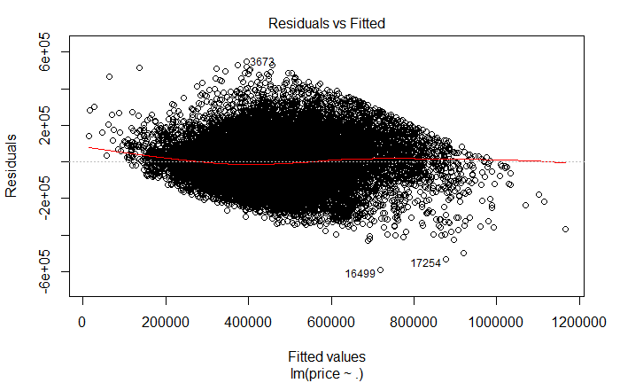

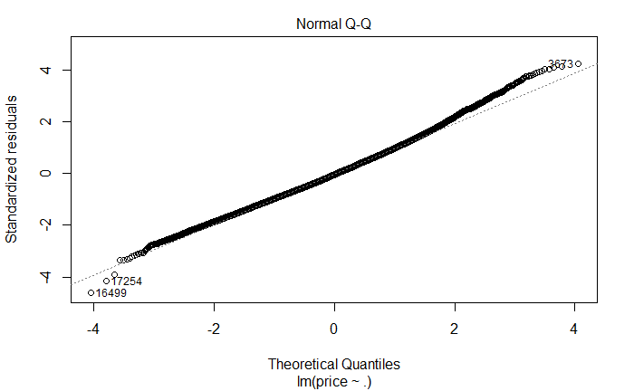

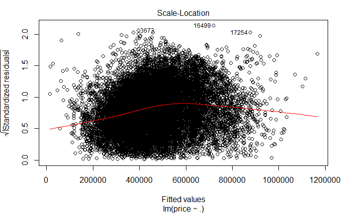

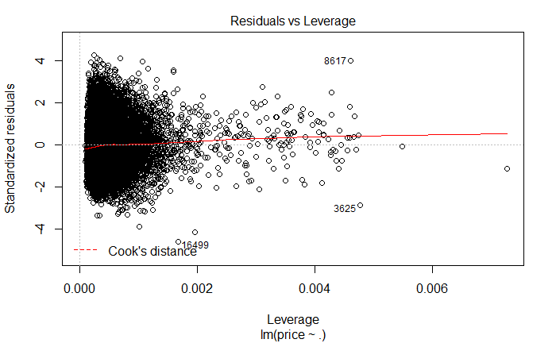

```r
####
plot(modelo_clean)
```

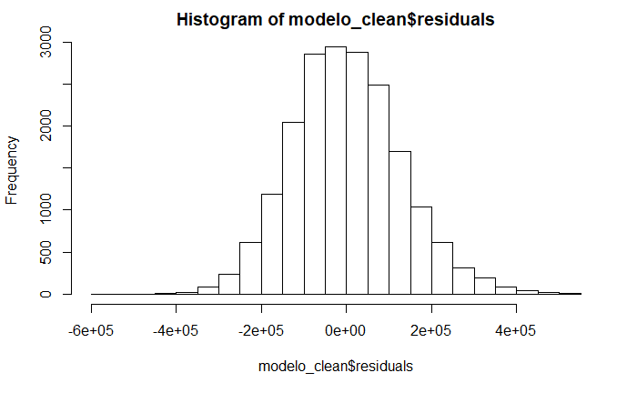

```r
hist(modelo_clean$residuals,breaks=40)
```

```r
modelo_clean1 <- lm(formula = log(price) ~ . , data =clean_data2 )


summary(modelo_clean1)
```

```
Call:
lm(formula = log(price) ~ ., data = clean_data2)

Residuals:
     Min       1Q   Median       3Q      Max
-1.66434 -0.20010  0.02122  0.21321  1.17470

Coefficients:
                Estimate Std. Error t value Pr(>|t|)
(Intercept)   -4.045e+01  4.348e+00  -9.303  < 2e-16 ***
bedrooms      -2.513e-03  2.926e-03  -0.859    0.391
bathrooms      1.270e-01  4.813e-03  26.379  < 2e-16 ***
floors         7.415e-02  5.131e-03  14.450  < 2e-16 ***
grade          1.970e-01  3.323e-03  59.279  < 2e-16 ***
zipcode        5.193e-04  4.435e-05  11.710  < 2e-16 ***
sqft_living15  2.077e-04  5.401e-06  38.450  < 2e-16 ***
sqft_lot15    -8.961e-07  2.207e-07  -4.060 4.93e-05 ***
antiguedad     5.795e-03  1.057e-04  54.841  < 2e-16 ***
---
Signif. codes:  0 ‘***’ 0.001 ‘**’ 0.01 ‘*’ 0.05 ‘.’ 0.1 ‘ ’ 1

Residual standard error: 0.2985 on 19360 degrees of freedom
Multiple R-squared:  0.5144,    Adjusted R-squared:  0.5142
F-statistic:  2564 on 8 and 19360 DF,  p-value: < 2.2e-16
```

```r
vif(modelo_clean1)
```

```
     bedrooms     bathrooms        floors         grade       zipcode sqft_living15    sqft_lot15
     1.438048      2.432178      1.648548      2.393670      1.226867      2.180276      1.135438
   antiguedad
     1.954938
```

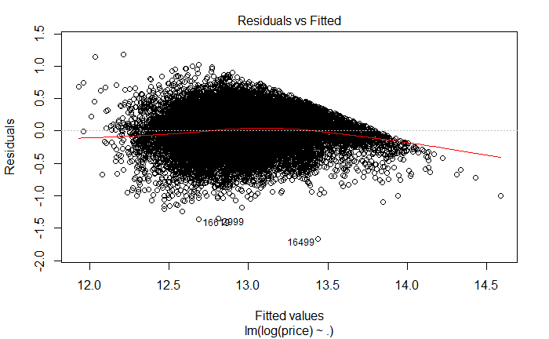

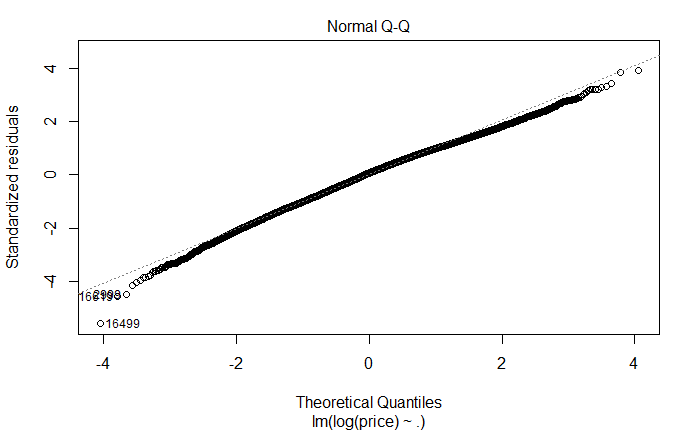

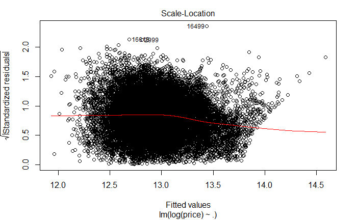

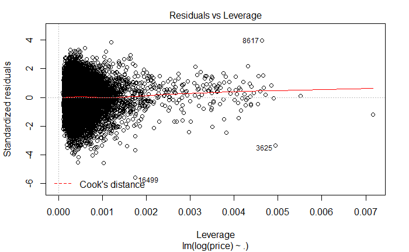

```r
####
plot(modelo_clean1)
```

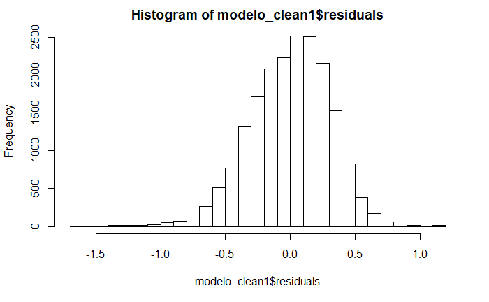

```r
hist(modelo_clean1$residuals,breaks=40)
```

### 4 Predict

```r
predicciones <- predict(object = modelo_clean, newdata = clean_data2, interval = "confidence", level = 0.95)
predicciones2 <- predicciones <- predict(object = modelo_clean, newdata = clean_data2, interval = "predict", level = 0.95)
summary(predicciones)
```

```
      fit               lwr               upr
 Min.   :   5453   Min.   :-246086   Min.   : 256992
 1st Qu.: 358646   1st Qu.: 107243   1st Qu.: 610045
 Median : 440717   Median : 189298   Median : 692122
 Mean   : 458641   Mean   : 207219   Mean   : 710062
 3rd Qu.: 538768   3rd Qu.: 287348   3rd Qu.: 790194
 Max.   :1170394   Max.   : 918411   Max.   :1422378
```

```r
summary(predicciones2)
```

```
      fit               lwr               upr
 Min.   :   5453   Min.   :-246086   Min.   : 256992
 1st Qu.: 358646   1st Qu.: 107243   1st Qu.: 610045
 Median : 440717   Median : 189298   Median : 692122
 Mean   : 458641   Mean   : 207219   Mean   : 710062
 3rd Qu.: 538768   3rd Qu.: 287348   3rd Qu.: 790194
 Max.   :1170394   Max.   : 918411   Max.   :1422378
```

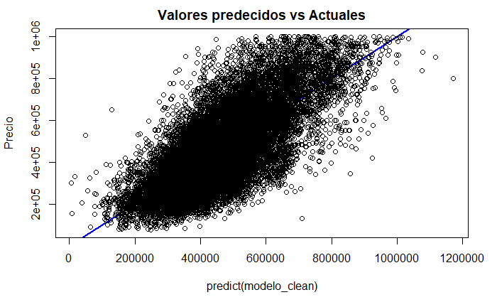

```r
plot(predict(modelo_clean), clean_data2$price, ylab="Precio", main = "Valores predecidos vs Actuales", abline(a=0, b=1, col="blue", lwd=2))
```

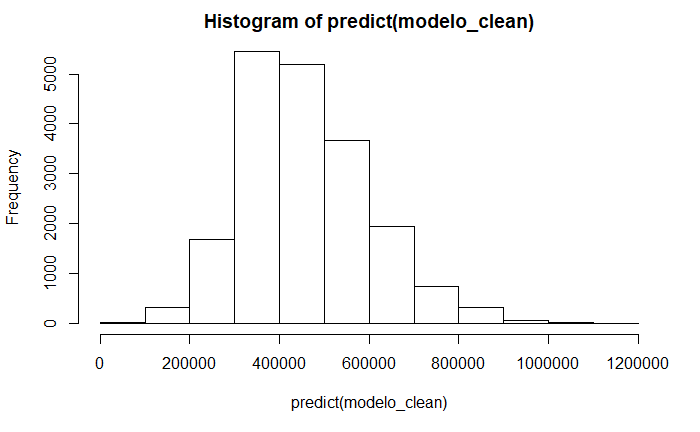

```r
hist(predict(modelo_clean))
```

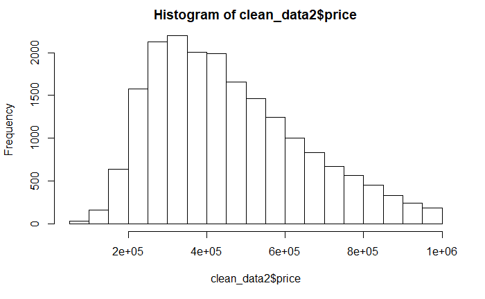

```r
hist(clean_data2$price)
```